#Name: Sweta Kumari #REGRESSION

#1. Data Inspection:Read the regression file and plot the graph between tannin and growth. Find the mean of growth then plot line with slope as 0 and inetrcept as mean of growth

```r
regression<-read.csv("C:\\Users\\Sweta\\Documents\\Data\\regression.csv",header=T)
attach(regression)
names(regression)
```

```
## [1] "growth" "tannin"
```

```r
plot(tannin,growth)
mean(growth)
```

```
## [1] 6.888889
```

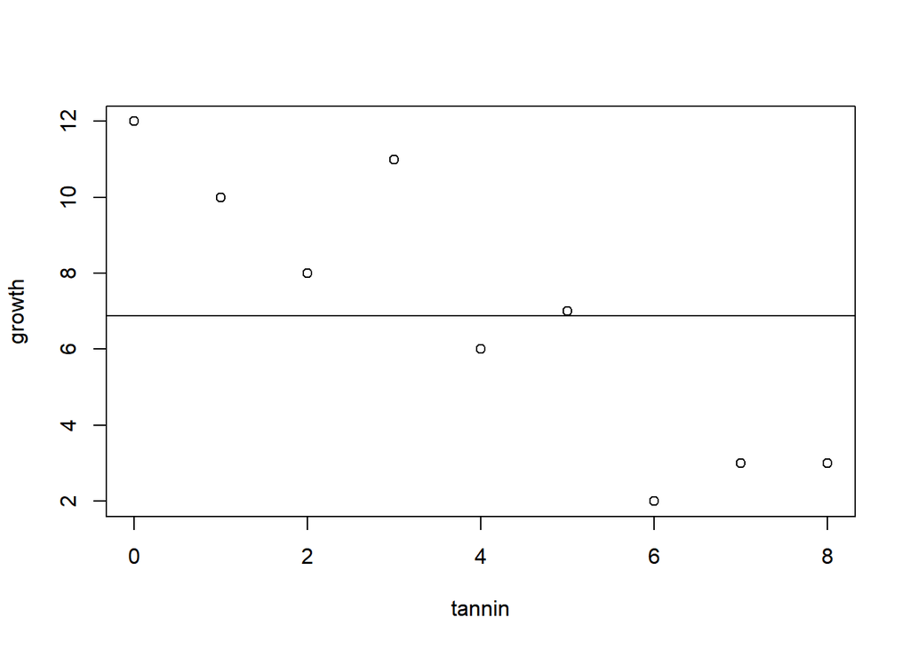

```r
abline(6.889,0)
```

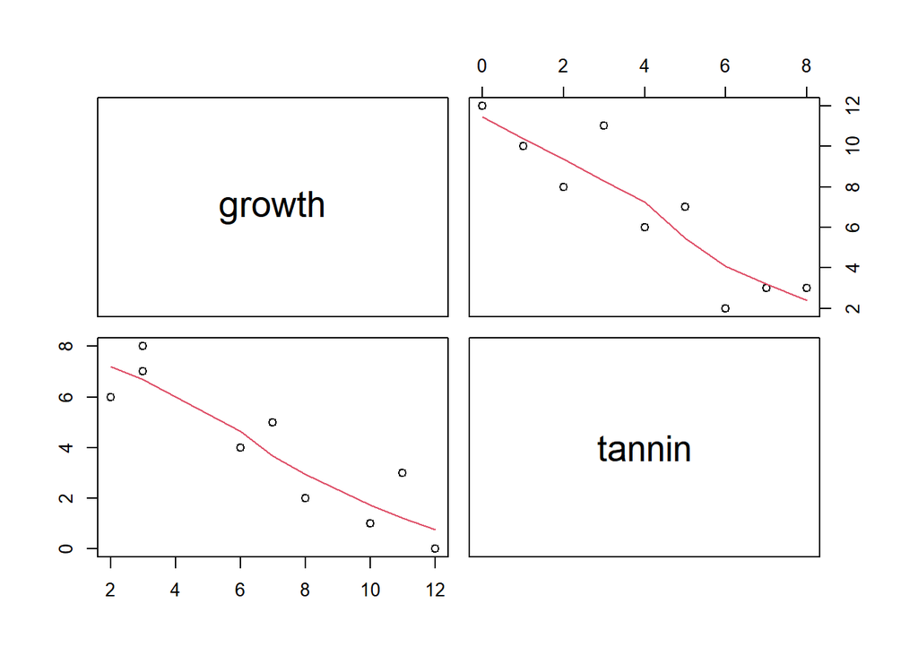

```r
pairs(regression,panel = panel.smooth)
```

```r
qt(.975,7)
```

```
## [1] 2.364624
```

#Calculations involved in linear regression

```r
regression
```

```
##   growth tannin
## 1     12      0
## 2     10      1
## 3      8      2
## 4     11      3
## 5      6      4
## 6      7      5
## 7      2      6
## 8      3      7
## 9      3      8
```

#Let say x is tannin and y is growth #Find sum of x and sum of x^2

```r
sum(tannin);sum(tannin^2)
```

```
## [1] 36
```

```
## [1] 204
```

#Find sum of y and sum of y^2

```r
sum(growth);sum(growth^2)
```

```
## [1] 62
```

```
## [1] 536
```

#Find sum of xy

```r
sum(tannin*growth)
```

```
## [1] 175
```

#quantiles of the F distribution

```r
qf(0.95,1,7)
```

```
## [1] 5.591448
```

#The probability of getting an F value of 30.98 if the null hypothesis of b = 0 is true.

```r
1-pf(30.98,1,7)
```

```
## [1] 0.0008455934
```

#To calculate the 95% confidence intervals: 2-tailed value of Student’s t with d.f=7.

```r
qt(.975,7)
```

```
## [1] 2.364624
```

#Using R for regression: Obtain scatter plot then add fitted line abline directive with lm (linear model)

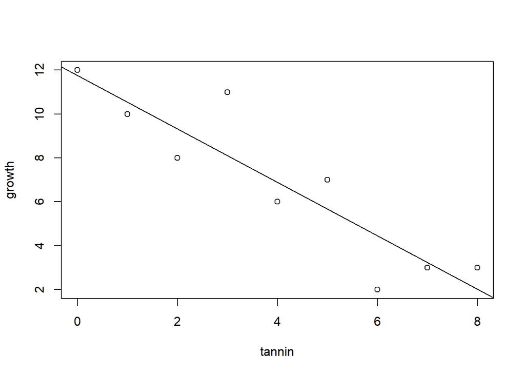

```r
plot(tannin,growth)
abline(lm(growth~tannin))
```

#Let’s called model object as “model”

```r
model<-lm(growth~tannin)
```

#Summarize the model:

```r
summary(model)
```

```
##
## Call:
## lm(formula = growth ~ tannin)
##
## Residuals:
##     Min      1Q  Median      3Q     Max
## -2.4556 -0.8889 -0.2389  0.9778  2.8944
##
## Coefficients:
##             Estimate Std. Error t value Pr(>|t|)
## (Intercept)  11.7556     1.0408  11.295 9.54e-06 ***
## tannin       -1.2167     0.2186  -5.565 0.000846 ***
## ---
## Signif. codes:  0 '***' 0.001 '**' 0.01 '*' 0.05 '.' 0.1 ' ' 1
##
## Residual standard error: 1.693 on 7 degrees of freedom
## Multiple R-squared:  0.8157, Adjusted R-squared:  0.7893
## F-statistic: 30.97 on 1 and 7 DF,  p-value: 0.0008461
```

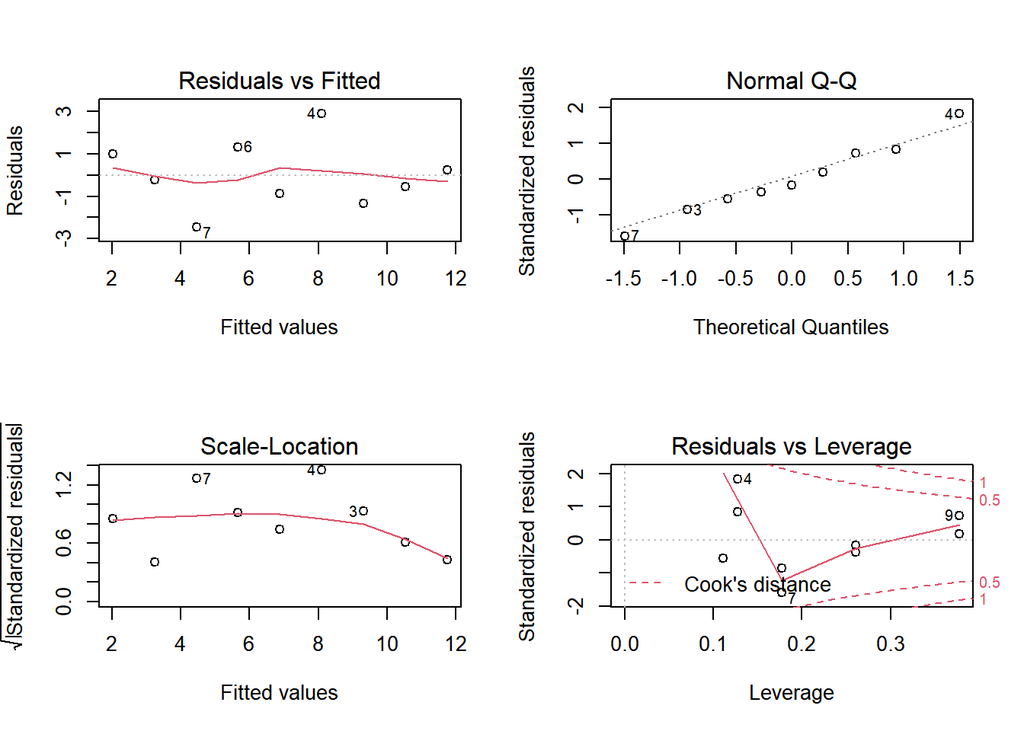

```r
par(mfrow=c(2,2))
plot(model)
```

#the predicted value of y hat at tannin = 5.5%

```r
11.7556-1.2167*5.5
```

```
## [1] 5.06375
```

#Alternate way is to use predict directive with object called model

```r
predict(model,list(tannin=5.5))
```

```
##        1
## 5.063889
```

#We will use mfrow to plot one graph in a row. If there is any x and y vector exist, it can be removed by rm:

```r
par(mfrow=c(1,1))
rm(x,y)
```

#Transformation of non-linear responses

```r
decay<-read.csv("C:\\Users\\Sweta\\Documents\\Data\\decay.csv",header=T)
attach(decay)
names(decay)
```

```
## [1] "time"   "amount"
```

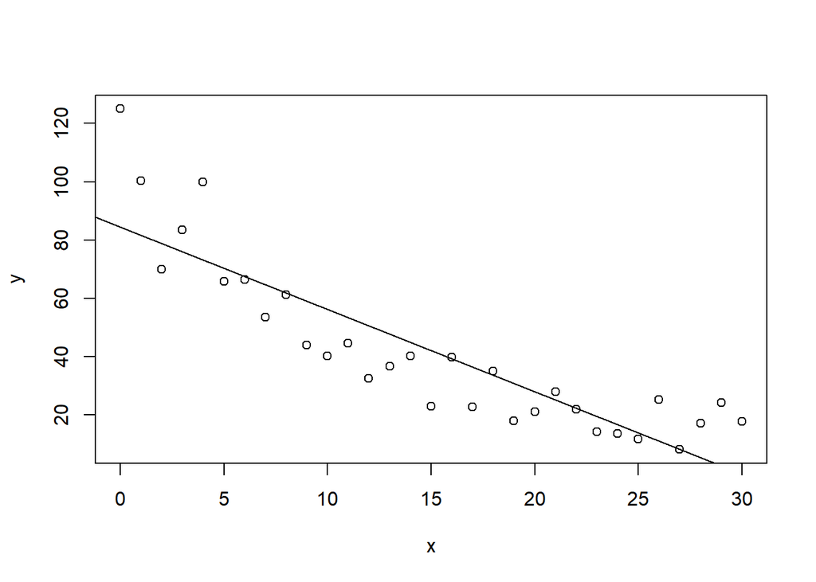

```r
x<-time
y<-amount
plot(x,y)
abline(lm(y~x))
```

#Let’s called model object as result

```r
result<-lm(y~x)
summary(result)
```

```
##
## Call:
## lm(formula = y ~ x)
##
## Residuals:
##     Min      1Q  Median      3Q     Max
## -19.065 -10.029  -2.058   5.107  40.447
##
## Coefficients:
##             Estimate Std. Error t value Pr(>|t|)
## (Intercept)  84.5534     5.0277   16.82  < 2e-16 ***
## x            -2.8272     0.2879   -9.82 9.94e-11 ***
## ---
## Signif. codes:  0 '***' 0.001 '**' 0.01 '*' 0.05 '.' 0.1 ' ' 1
##
## Residual standard error: 14.34 on 29 degrees of freedom
## Multiple R-squared:  0.7688, Adjusted R-squared:  0.7608
## F-statistic: 96.44 on 1 and 29 DF,  p-value: 9.939e-11
```

#Diagnostic plot

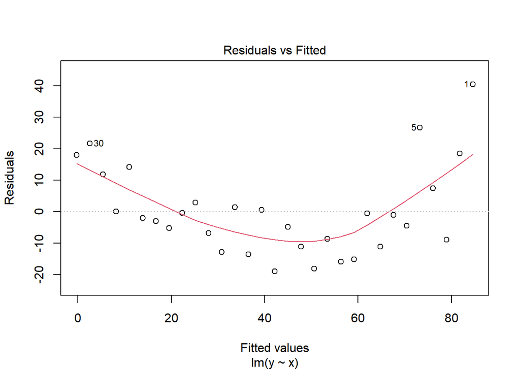

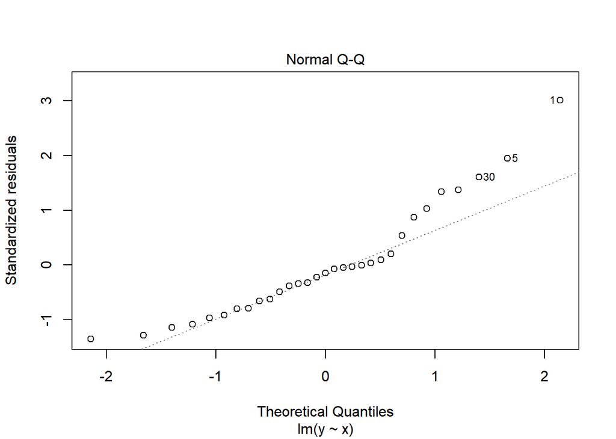

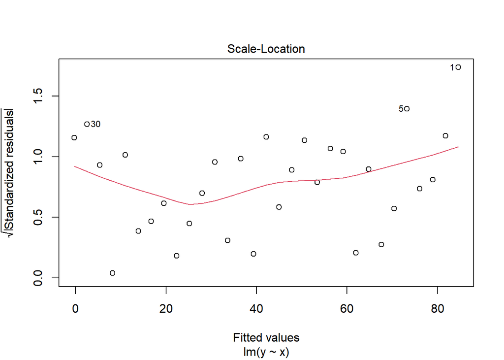

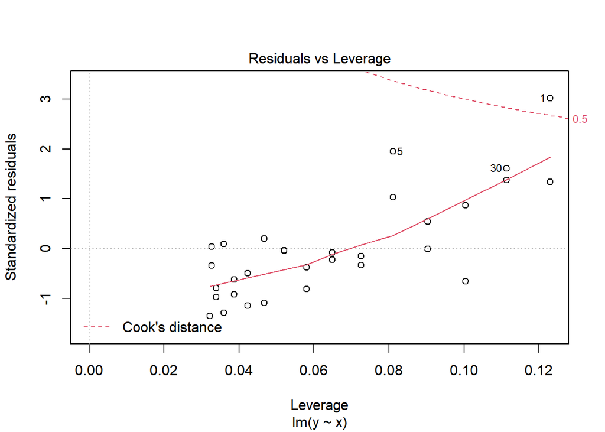

```r
plot(result)
```

#Plot the graph for x vs ln y

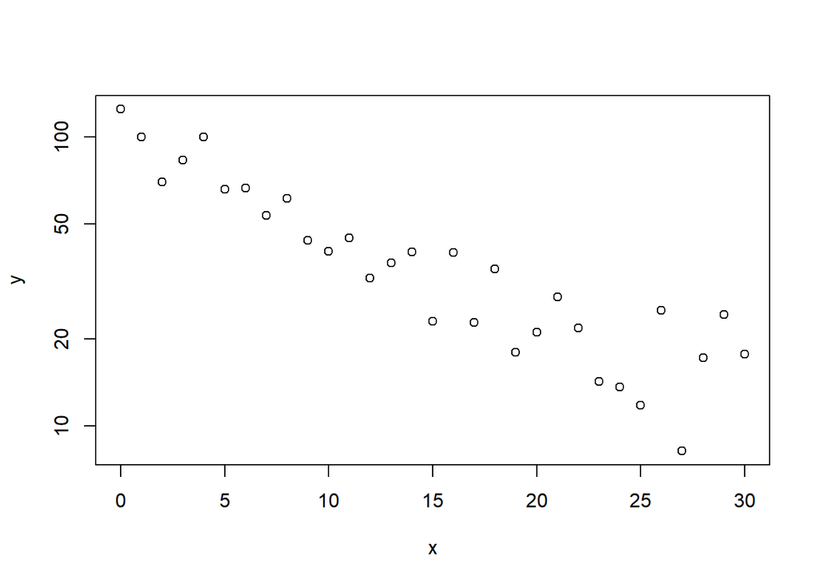

```r
plot(x,y,log="y")
```

#Let’s say new model object is “transformed”

```r
transformed <- lm(log(y)~x)
summary(transformed)
```

```
##
## Call:
## lm(formula = log(y) ~ x)
##
## Residuals:
##     Min      1Q  Median      3Q     Max
## -0.5935 -0.2043  0.0067  0.2198  0.6297
##
## Coefficients:
##              Estimate Std. Error t value Pr(>|t|)
## (Intercept)  4.547386   0.100295   45.34  < 2e-16 ***
## x           -0.068528   0.005743  -11.93 1.04e-12 ***
## ---
## Signif. codes:  0 '***' 0.001 '**' 0.01 '*' 0.05 '.' 0.1 ' ' 1
##
## Residual standard error: 0.286 on 29 degrees of freedom
## Multiple R-squared:  0.8308, Adjusted R-squared:  0.825
## F-statistic: 142.4 on 1 and 29 DF,  p-value: 1.038e-12
```

#Let’s check the diagmostic plot:

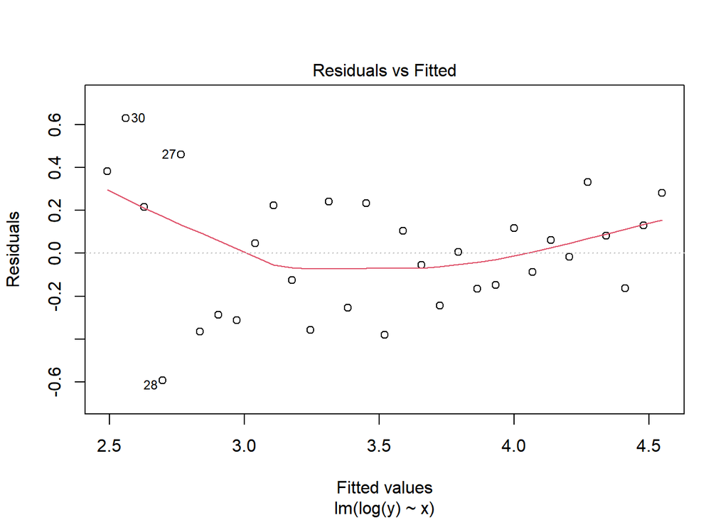

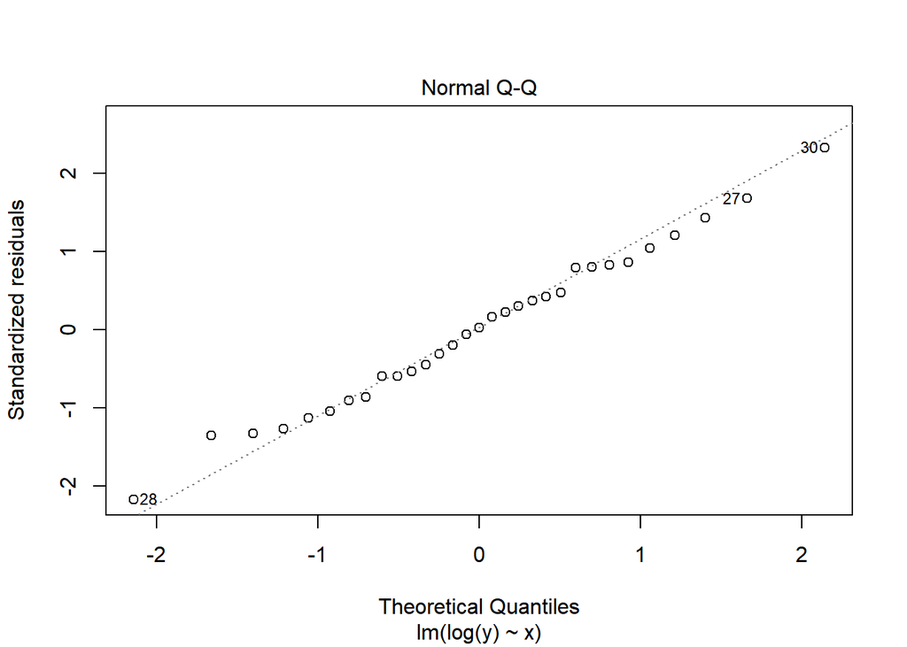

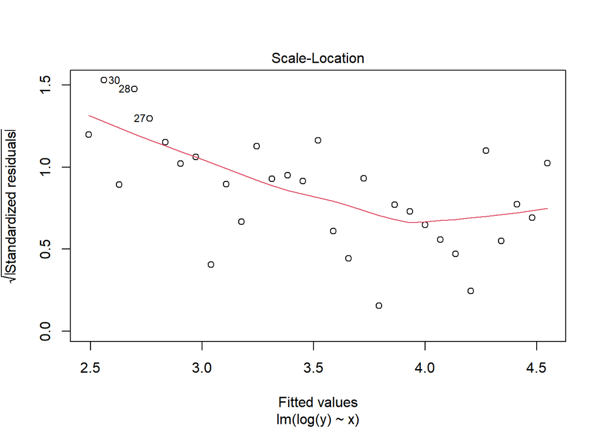

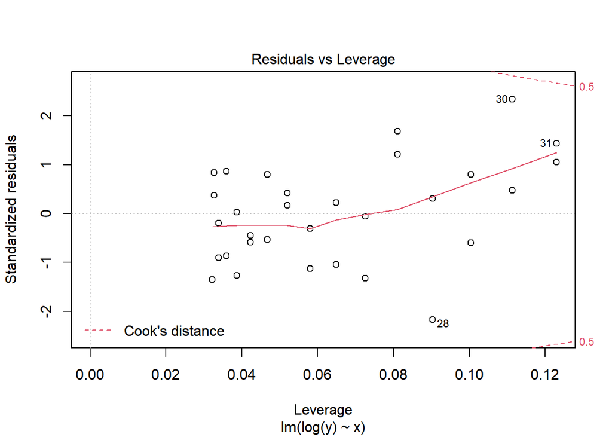

```r
plot(transformed)
```

#Let’s redraw the scatter plot for x and y

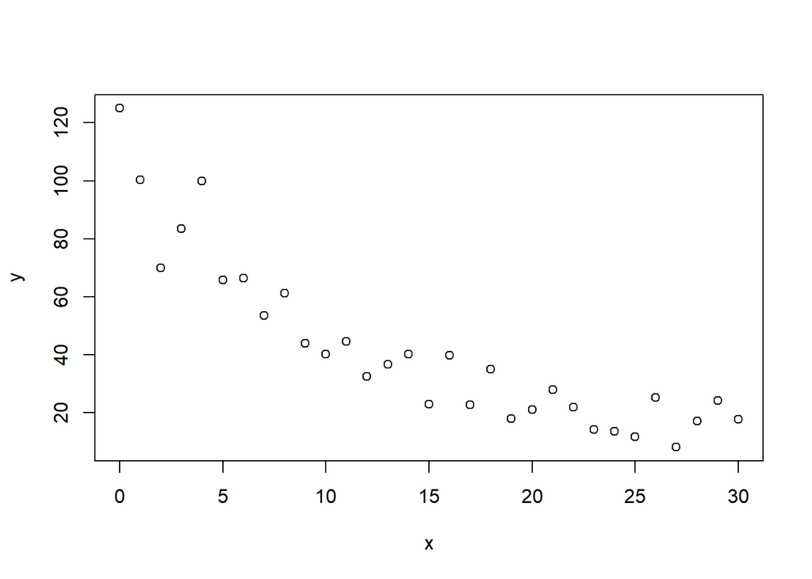

```r
plot(x,y)
```

#Let’s generate sequence from 0 to 30 with inetrval 0.1 and predict the respective value of y:

```r
smoothx<-seq(0,30,0.1)
smoothy<-exp(predict(transformed,list(x=smoothx)))
```

#Draw the fitted line:

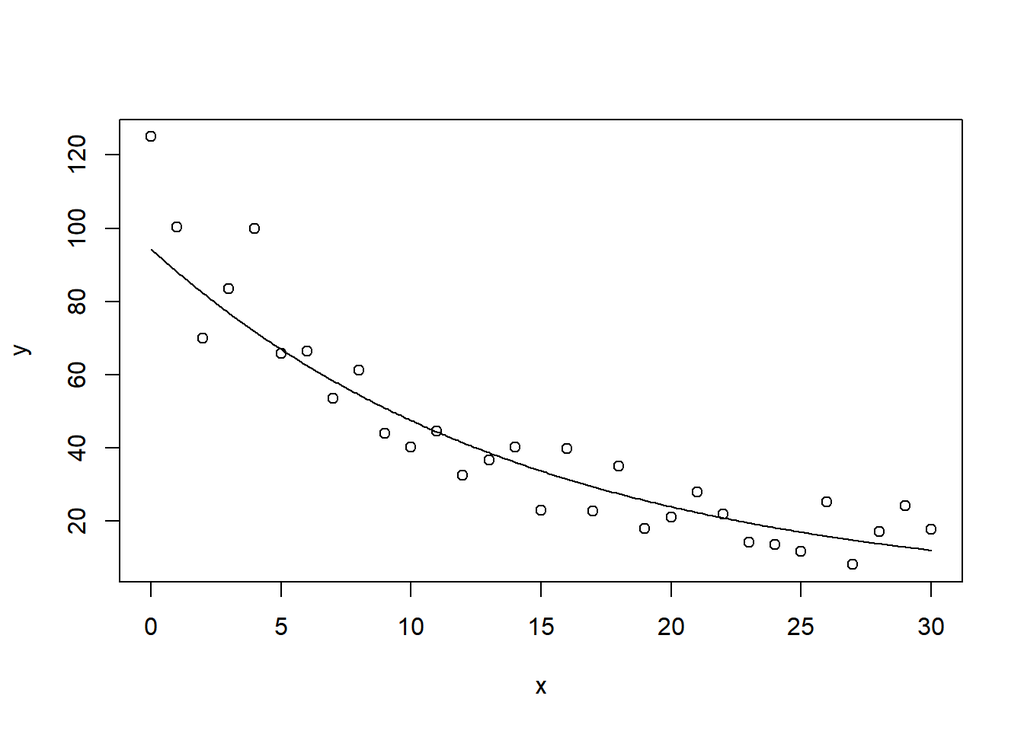

```r
plot(x,y)
lines(smoothx,smoothy)
```